# Nuforc Sightings Analysis

Savannah

2025-09-26

# File Setup:

These are all the libraries needed for this analysis.

```r
library(readr)
library(tidyverse)
```

```r
library(ggplot2)
library(stopwords)
library(RColorBrewer)
library(wordcloud)
library(tidytext)
```

# Task 1: Building the Shape Table

## Filtering and cleaning the data:

First, I will read in the data:

```r
raw_df<- read_csv("nuforc_sightings.csv")
state_map <- read_csv("states.csv")
```

```
## ──────────────────────────────────────────────────────── Delimiter: "," chr
## (2): state, name dbl (1): ...1
```

To filter the data, I used the states.csv for abbreviations of states. Additionally, some states mismatched to other countries so I corrected that in the filtering as well.

```r
USA_df <- raw_df %>% mutate(state = tolower(state),
                            country = tolower(country),
                            shape = tolower(shape)) %>%
  filter(state %in% state_map$state | country == 'usa') %>%
  mutate(state = recode(state,"ohio" = "oh",
                        "new york" = "ny", "montana" = "mt",
                        "west virginia" = "wv", "wisconsin" = "wi")) %>%
  filter(state %in% state_map$state | state == "-" |
           state == "0" | state == "dc")
```

With this data, I standardized the shape column, removing all empty strings and turning them into “unknown”.

```r
stand_shape <- USA_df %>%
  mutate(shape = ifelse(is.na(shape) | shape == "", "unknown",shape))
```

## Creating the pivot table:

```r
shape_by_state <- stand_shape %>% group_by(state, shape) %>%
  summarise(count = n(), .groups = "drop")

shape_state_pivot <- shape_by_state %>% pivot_wider(
  names_from = shape, values_from = count, values_fill = 0)
```

There are 22 shapes in total excluding unknown and other. California/ CA saw the most circular shapes.

# Task 2: PCA on the Shape Table

## Row-normalizing the table and PCA:

```r
#Row normalization
shape_state_norm <- shape_state_pivot %>% rowwise() %>%
  mutate(total = sum(c_across(-state))) %>%
  mutate(across(-c(state, total), ~ .x / total)) %>%
  select(-total) %>%
  ungroup()

# Performing PCA:
pca_shape <- prcomp(shape_state_norm[, -1], center = TRUE, scale. = TRUE)
```

## Proportion of variance explained and scree plot:

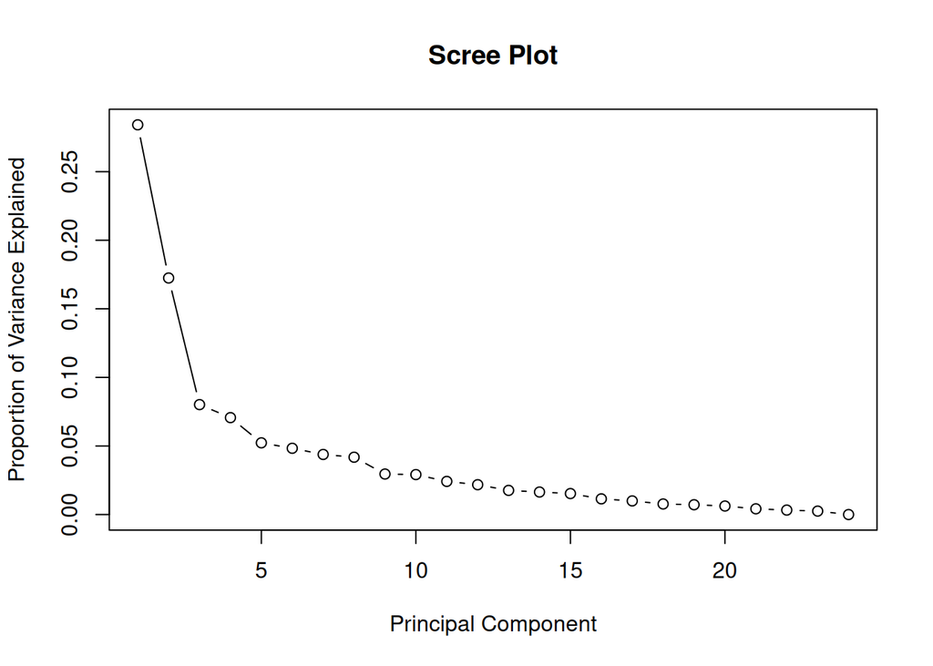

```r
pve_shape <- (pca_shape$sdev)^2 / sum(pca_shape$sdev^2)

plot(pve_shape, type = "b", xlab = "Principal Component",
     ylab = "Proportion of Variance Explained", main = "Scree Plot")
```

It does seem that the variety of UFO sightings can be boiled down to a few key patterns. Based on the scree plot, the proportion of variance explained by the first few principle components are enough to cover the majority of variance in the data.

## Scatterplot:

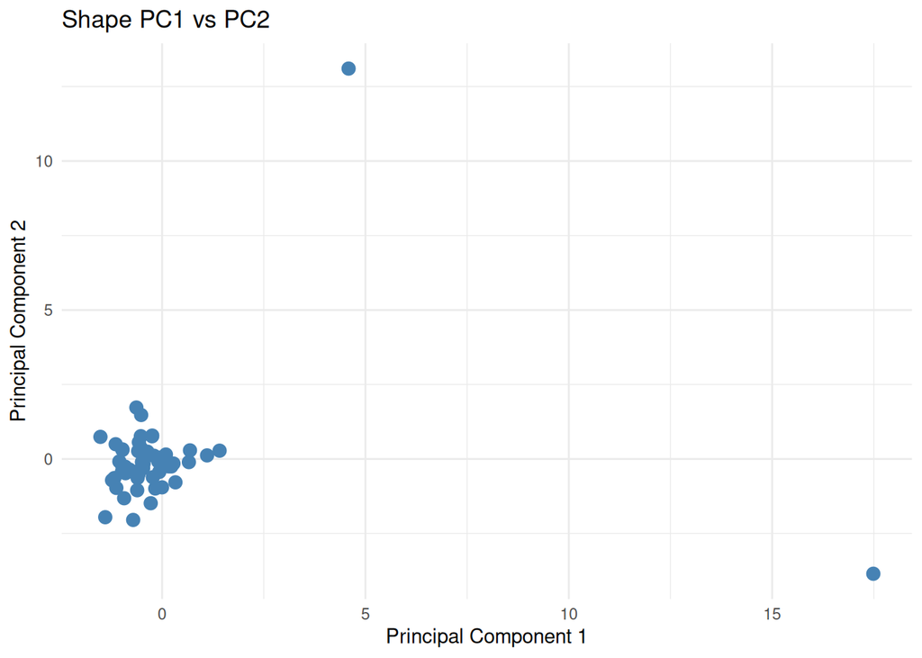

```r
pca_shape_df <- as.data.frame(pca_shape$x)

ggplot(pca_shape_df, aes(x = PC1, y = PC2)) +
  geom_point(color = "steelblue", size = 3) +
  labs(title = "Shape PC1 vs PC2",
       x = "Principal Component 1",
       y = "Principal Component 2") +
  theme_minimal()
```

Based on the scatterplot, the majority of states seem to be in one cluster. There are two states that exhibit outlier tendencies.

## Examining the PCA rotation:

```r
rotation_tbl <- as.data.frame(pca_shape$rotation) %>%
  round(3) %>% .[,c(1,2)] %>%
  rownames_to_column(var = "Variable")
print(rotation_tbl)
```

```
##     Variable    PC1    PC2
## 1   changing -0.199  0.277
## 2      cigar -0.180  0.216
## 3     circle  0.351 -0.162
## 4      cross -0.039  0.205
## 5       cube  0.080  0.430
## 6   cylinder -0.076  0.305
## 7       disk -0.278 -0.061
## 8   fireball -0.252 -0.133
## 9  formation -0.234 -0.051
## 10     light -0.287 -0.113
## 11       orb -0.200  0.188
## 12     other -0.234  0.295
## 13      oval -0.222  0.083
## 14 rectangle -0.178  0.186
## 15    sphere -0.273 -0.156
## 16  triangle -0.219 -0.025
## 17   unknown -0.019  0.409
## 18   chevron -0.169 -0.134
## 19      cone -0.147 -0.088
## 20   diamond -0.229 -0.190
## 21       egg -0.185 -0.176
## 22     flash -0.192 -0.146
## 23  teardrop -0.174 -0.122
## 24      star -0.107 -0.093
```

# Task 3: Clean and Tokenize Summaries

## To clean up the summaries:

```r
Encoding(USA_df$summary) <- "UTF-8"
clean_summary <- USA_df %>%
  mutate(summary = tolower(summary)) %>%
  mutate(summary = iconv(summary, from = "UTF-8", to = "ASCII", sub = "")) %>%
  mutate(summary = gsub("\\s+", " ", trimws(summary)))
```

## Making an array of words and removing punctuation:

```r
word_array <- clean_summary %>% mutate(words = strsplit(summary, split = " "))
all_words <- unlist(word_array$words) %>% gsub("[[:punct:]]", "", .)
```

## Frequency of each word:

```r
freq_word <- table(all_words) %>% as.data.frame(.)
colnames(freq_word) <- c("word", "frequency")
freq_word <- freq_word[order(-freq_word$frequency), ]
```

## Table and word cloud:

```r
print(head(freq_word,50))
```

```
##           word frequency
## 43917      the     64752
## 6217         a     57344
## 24340       in     57309
## 7511       and     47415
## 32077       of     36315
## 26941   lights     31450
## 26778    light     30389
## 23911        i     29872
## 40188      sky     29839
## 44459       to     29086
## 47333      was     23749
## 10875   bright     22851
## 31634   object     22755
## 33028     over     20570
```

[output cut: 36 more lines]

I chose to visualize this via a table. It is a very large table, so I only printed the first 50 rows.

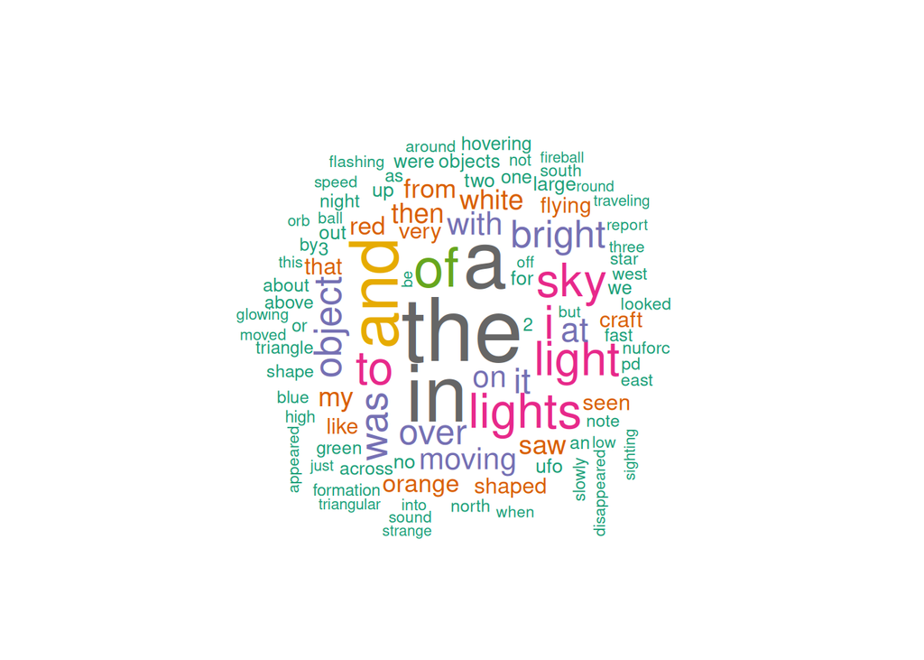

```r
top_100_unclean <- head(freq_word, 100)
wordcloud(words = top_100_unclean$word,
          freq = top_100_unclean$frequency,
          min.freq = 1,
          random.order = FALSE,
          colors = brewer.pal(8, "Dark2"))
```

The most frequent words are generally generic English words or generic words used to describe UFOs.

## Removing stopwords from all_words:

```r
all_words_clean <- all_words[!all_words %in% stopwords('en')]

clean_word <- table(all_words_clean) %>% as.data.frame(.)
colnames(clean_word) <- c("word", "frequency")
clean_word <- clean_word[order(-clean_word$frequency), ]
```

## Histogram of cleaned words:

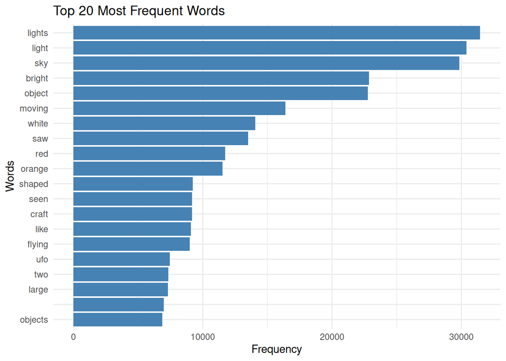

```r
top_20 <- head(clean_word, 20)

ggplot(top_20, aes(x = reorder(word, frequency), y = frequency)) +
  geom_bar(stat = "identity", fill = "steelblue") +
  coord_flip() +  # Flips to horizontal bars
  labs(title = "Top 20 Most Frequent Words",
       x = "Words",
       y = "Frequency") +
  theme_minimal()
```

From the top frequent words after cleaning, we find the words “light”/“lights”/“bright”, “sky”, and “moving” as some of the top characterizations of UFO sightings

# Task 4: Building the Keywords Table and PCA

## Defining the dictionary of 100 words:

```r
top_100 <- clean_word %>%
  filter(nchar(as.character(word)) >= 3) %>%
  slice_max(order_by = frequency, n = 100)
```

## To make table of frequencies by state:

```r
top100_df <- data.frame(word = top_100$word)
tokenized_df <- clean_summary %>%
  select(state, summary) %>%
  unnest_tokens(word, summary) %>%
  filter(word %in% top100_df$word)

word_state_pivot <- tokenized_df %>%
  count(state, word, sort = TRUE) %>%
  pivot_wider(names_from = word, values_from = n, values_fill = 0)

print(word_state_pivot)
```

```
## # A tibble: 53 × 101
##    state light   sky lights object bright moving white   red orange   saw  like
##    <chr> <int> <int>  <int>  <int>  <int>  <int> <int> <int>  <int> <int> <int>
##  1 ca     3899  3649   3558   3014   2780   1872  1846  1685   1597  1555  1472
##  2 fl     1786  1944   1781   1432   1368   1080   832   893   1169   871   729
##  3 wa     1831  1589   1501   1142   1388    917   857   733    728   729   547
##  4 az     1074  1111   1432    814    877    540   566   486    521   433   373
##  5 tx     1429  1385   1388   1144    952    755   709   491    440   667   509
##  6 ny     1320  1375   1308   1090   1002    763   657   607    617   680   447
##  7 pa     1146  1274   1247    896    931    674   616   606    650   522   399
##  8 il      946  1064   1132    737    680    533   434   595    495   448   293
##  9 oh      949  1019   1127    709    697    549   522   499    564   471   355
## 10 nc      875   823    993    645    657    528   414   419    483   380   276
## # ℹ 43 more rows
## # ℹ 89 more variables: shaped <int>, flying <int>, seen <int>, craft <int>,
## #   ufo <int>, two <int>, objects <int>, blue <int>, large <int>, nuforc <int>,
## #   note <int>, night <int>, green <int>, star <int>, hovering <int>,
## #   shape <int>, high <int>, one <int>, fast <int>, across <int>,
## #   triangle <int>, east <int>, north <int>, formation <int>, looked <int>,
## #   slowly <int>, west <int>, south <int>, three <int>, speed <int>, …
```

## Performing Task 2 for this table

### Row-normalizing the table:

```r
word_state_norm <- word_state_pivot %>% rowwise() %>%
  mutate(total = sum(c_across(-state))) %>%
  mutate(across(-c(state, total), ~ .x / total)) %>%
  select(-total) %>%
  ungroup()
```

### Performing PCA:

```r
pca_word <- prcomp(word_state_norm[, -1], center = TRUE, scale. = TRUE)
```

### Proportion of variance explained & scree plot:

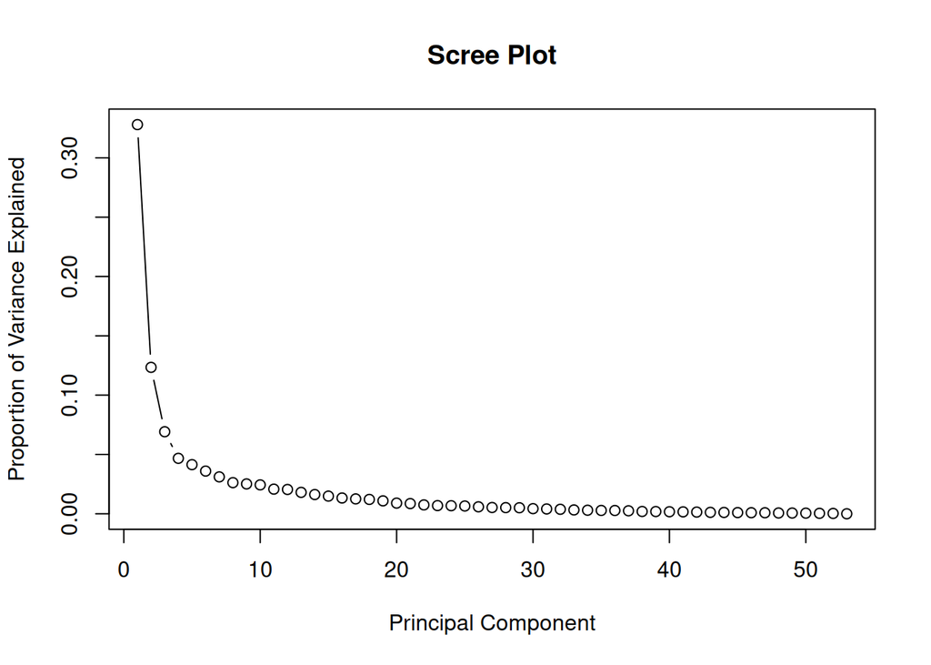

```r
pve_word <- (pca_word$sdev)^2 / sum(pca_word$sdev^2)
plot(pve_word, type = "b", xlab = "Principal Component",
     ylab = "Proportion of Variance Explained", main = "Scree Plot")
```

Similar to the shape by state data, this word count by state data also seems to be boiled down to a few patterns/ principle components. The majority of the variance is described by the first few principle components. The proportion of variance defined by latter PCs dwindle.

### Scatterplot:

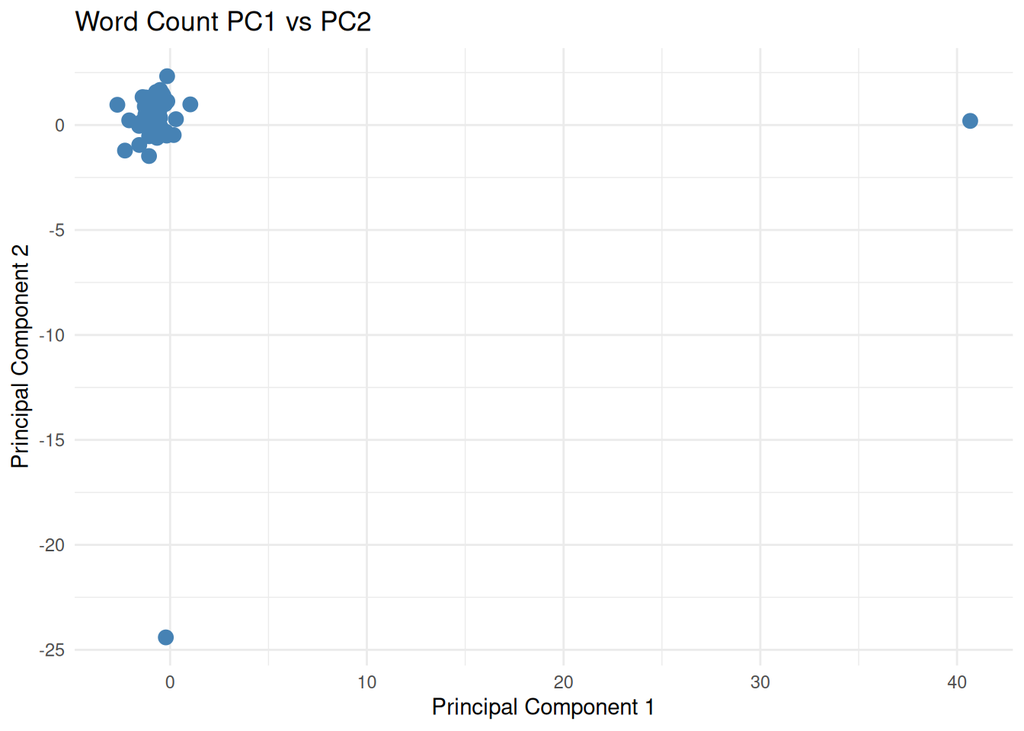

```r
pca_word_df <- as.data.frame(pca_word$x)

ggplot(pca_word_df, aes(x = PC1, y = PC2)) +
  geom_point(color = "steelblue", size = 3) +
  labs(title = "Word Count PC1 vs PC2",
       x = "Principal Component 1",
       y = "Principal Component 2") +
  theme_minimal()
```

Similarly to the shape scatterplot, the majority of states seem to be in one cluster. There are again two states that seem to be outliers.

### PCA rotation:

```r
rotation_word_tbl <- as.data.frame(pca_word$rotation) %>%
  round(3) %>% .[,c(1,2)] %>%
  rownames_to_column(var = "Variable")
print(rotation_word_tbl)
```

```
##        Variable    PC1    PC2
## 1         light  0.140  0.085
## 2           sky  0.139  0.119
## 3        lights -0.129  0.030
## 4        object -0.143 -0.013
## 5        bright  0.170  0.033
## 6        moving -0.140  0.050
## 7         white -0.117  0.145
## 8           red -0.122  0.003
## 9        orange -0.068  0.092
## 10          saw  0.144 -0.147
## 11         like  0.170 -0.049
## 12       shaped -0.130 -0.046
## 13       flying -0.118  0.030
## 14         seen -0.102 -0.183
```

[output cut: 86 more lines]

The words “bright”, “light”, “star”, “across”, “orb”, and “blinking” do suggest correlation with the shapes that were observed to be of primary drivers in the previous PCA. In general, the shapes that were most similarly described in this PCA are light”, “sphere”, “unknown” and “disk”. The shapes “rectangle” and “cube” are less accurately described by these top words.